# Medicaid Expansion Effects on Labor Decisions

Colin Wick

5/12/2021

### Background & Intro

The average health insurance premium cost for a single individual rose from $3,000 to $7,000 from 1999 to 2018. Over the same period, family coverage increased from $6000 to $20,000 per year Health Affairs (2018) . In 2010, the Affordable Care Act included provisions for expansion of Medicaid for low-income individuals up to 138% of the federal poverty line. Though not a perfect program, qualifying for Medicaid, in a sense, represents a transfer of value to an individual or family, respectively, at no cost.

After clearing the initial Supreme Court challenges, 27 states expanded Medicaid on the first year of the program’s availability with another 10 expanding over the following 7 years. 4 states are currently in the process of implementing their expansions.

Given the stark cutoff of eligibility and relatively large income transfer that the program represents, bunching around the eligibility cutoff would be expected. This would be consistent with Saez (2010). However, in Miller (2019) they find little evidence of the kind of bunching present around the EITC trapezoid vertices. However, access to Medicaid is very different in terms of both public awareness and access. Even without bunching around the cutoff, there may still be some influence on labor decisions (or reporting) based on expanding eligibility.

Analysis from the Kaiser Family foundation found that removal of the asset test only resulted in a 3% increase in program uptake, meaning eligibility and qualification mainly rest on family income. Using this assumption, we are able to reconstruct Medicaid eligibility using reported family income from the ASEC (the economic supplement to the Census’s CPS). Income-based Medicaid eligibility is computed as a function of the Federal poverty line, which itself is a function of family size. Each of these variables is included in the ASEC (variables: NCHILD, FTOTVAL, MARST). Then using year-state Medicaid eligibility cutoffs as reported by the Kaiser Family Foundation, each observation of the ASEC can be coded with the exact difference between their family income and the state-year Medicaid threshold.

#### Definition of Population of Interest

This study specifically analyzes the population of families within $10,000 of Medicaid coverage in either direction. This is the rough estimate of the “Medicaid gap” which conceptually developed alongside the ACA’s implementation but existed before as well. Though a relatively arbitrary cutoff, the $10,000 cutoff is made where those at the high end would qualify for ACA Silver Plan Benchmarks and Medicaid coverage would not be worth reducing income. Similarly, for the low end, $10,000 represents adding 2 full 8-hour days of work at $12/hr. This cutoff represents utting down all Americans to a reasonable population represents those who are certainly affected by Medicaid’s income cutoff out to the edges of that income-qualification decision.

The population of interest is workers age 26-60. This population represents those most closely on the margin of the Medicaid cutoff. By the same logic other studies cut off health outcomes at the near-Medicare cohort, this study rather focuses on those for whom exogenous health effects may play less of a role in labor decisions. The lower bound of 26 is chosen due to the ACA’s rule allowing children to stay on parent’s health insurance policy until 26, which would distort estimates. I further limit the data to those who worked within the past year and did not report disability income to focus on marginal hours and wages rather than entering the labor force.

#### Theoretical Basis

Under the current system of Medicaid qualification, if a family is below their state’s threshold, they qualify for the program. There are cases where disabled people and children have extra access to similar programs without means testing or with higher thresholds. However, the coverage offered for Medicaid/Medicare disability, CHIP, or similar programs often does not extend to parents or caretakers.

Healthcare in the United States is completely unaffordable, especially among the population where Medicaid coverage is a relevant question. As established before, insurance premiums cost on average $6,000 per year for an individual. Under a utility-maximizing theory of households, access to healthcare is at least 1:1 substitutable with cash on hand, if not more. Therefore, if a worker is near the Medicaid threshold, they will adjust income (if possible) to get access to the program so long as the change in income is less than the in-kind utility of the program.

Countless economic research demonstrates wage stickiness for both hourly and salaried employees. However, even for relatively powerless people (hourly workers at the bottom of the income distribution), they can still exert some control over the marginal number of hours they work per week. This may mean taking an extra shift or dropping a shift, for example.

Small shifts in weekly hours can amount to relatively large changes in yearly income, to the point where it may affect household Medicaid eligibility. For example, dropping one 8-hour shift per week represents a $4,000 change in yearly income for a 50-week $10/hour worker. For those making between $10,000 and $20,000 (the Medicaid-expansion relevant population), this could represent the difference between qualifying and not qualifying. It is also immediately clear that this difference would represent a net +$2,000 household income increase taking the $6,000 average cost of an individual plan.

#### Visual Parallel Trends

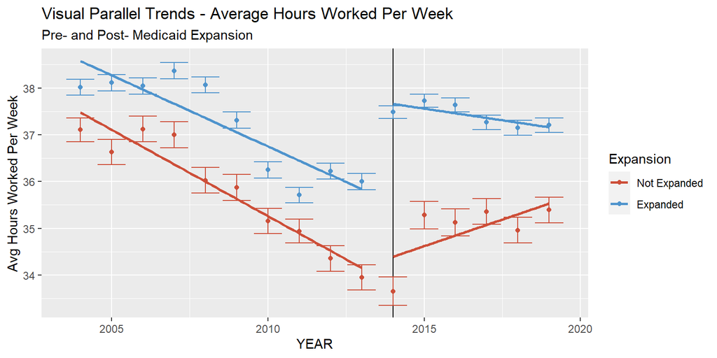

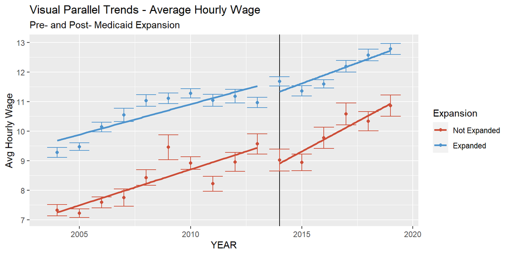

The next step is to statistically define these parallel trends using an event-study methodology to ensure there are measurable differences in the treated population over this time period for our variable of interest (Medicaid eligibility).

## Methodology & Establishing Causal Baseline

The intention of the study is to focus on a more narrow question. For those near the Medicaid eligibility cutoff, did the “shock” of the ACA cause those around the cutoff to increase their economic output, as measured by weekly hours.

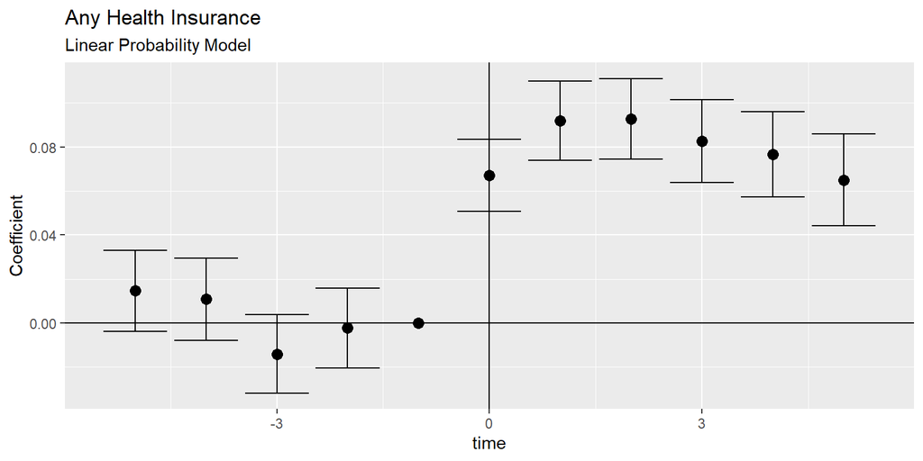

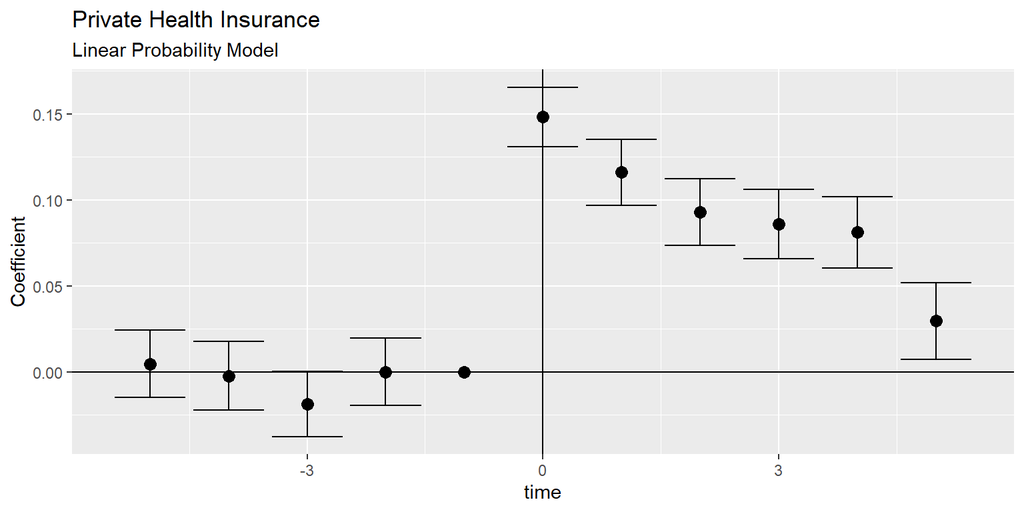

This one is interesting, because we find an increase in private health insurance uptake. This is partially explained by the ACA subsidies which brought down the cost of private insurance for households and the upper side of this population’s income distribution may qualify depending on the number of children in their family and state-level health insurance arrangement.

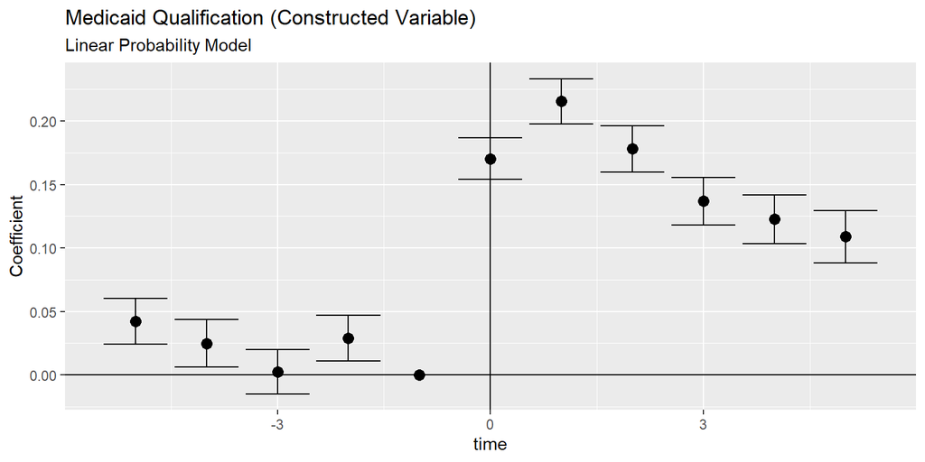

For the population of interest, we find that treatment had a dramatic effect on insurance rate. This is consistent with Miller 2019, both reaffirming the eligibility construction and showing that there are detectable state-level effects on insurance rates.

The first step in this analysis established that there may be a detectable treatment effect over time, but it is also necessary to establish this across the medicaid income threshold before and after treatment. The effects of increasing the medicaid threshold affect those above and below differently, so those just above may reduce hours while those below may increase hours when the Medicaid cutoff becomes a relevant choice in labor decisions. The next step in shaving off other potential causal factors is differences by demographics across the relevant threshold. Similar to the work in Hansen (2015) which shows that there is not a relevant discontinuity across the BAC threshold.

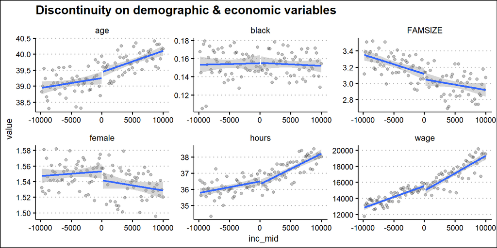

#### Placebo & Weighting

The process of post-constructing medicaid eligibility also yields a simple placebo mechanism by which the outcomes of a difference in differences can be measured. The standard conception of the medicaid gap is $10,000, meaning those outside of that threshold on either side will not face the same kind of imminent consideration on labor decisions, but will still have similar demographics and constraints as those just over the $10,000 threshold.

Similarly, those closest to the Medicaid threshold could stand to gain the most from qualifying (or disqualifying) for Medicaid, which motivates the use of RDD-style triangular or quadratic weighting mechanism for those closest to that threshold to upweight the marginal decisions of those who are closest. This intuitively makes sense, since someone who merely needs to work one-fewer shifts per month, or one-fewer hours per week may opt to do so when that would qualify them for medicaid. Similarly, those who might have been bunching just-below the threshold have flexibility to work the corresponding marginal hour. On the contrary, few people (especially those for whom Medicaid is relevant) will not be able to simply choose to make or forego $10,000 based on marginal labor decisions.

## Model Specification

The first model employed is a standard difference-in-difference model to establish a relationship with respect to expansion. In this sample, only looking at states which expanded immediately after the law went into effect. Where each individual ($i$) in state ($s$) is treated at time ($t$) with controls for each state and year effects, as well as a vector of demographic control variables $\mu$. For this regression, using the formula:

$H_{i,s,t} = \alpha + \gamma \cdot Treat + \beta \cdot Post + \delta \cdot Treat \cdot Post + \mu_i + \epsilon$

Second model employs the strategy highlighted in Black (2019) and Miller (2019), which accounts for lingering effects of treatment, setting “D” as a dummy representing ever receiving treatment and R representing a dummy for each relative event time. Using the formula:

$H_{i,t,s} = \alpha + \gamma*(D=1) + \delta (R_{t,s}=1) + \beta_s + \beta_t + \mu_{i} + \epsilon_{i,s,t}$

To estimate whether these effects are most prevalent on the margin, I employ a weighted regression model using both a triangular and quadratic scheme following the following formulas. A triangular scheme will greatly weight the effects for those closest to the relevant margin, while the quadratic model will maintain the weights for those slightly further away from the threshold.

$W_{tri} = 1-\frac{abs(x)-10000}{10000} * W_{ASEC}$

$W_q = 1-\frac{x^2}{10000^2} * W_{ASEC}$

The weighting scheme equals 1 for those directly on the threshold, and eventually equals 0 for those furthest. This method is commonly employed in a regression discontinuity design, but is relevant in this case for isolating *whether* this effect is happening on the margin or across the entire workforce. By isolating this marginal movement as statistically distinct from the entire near-medicaid workforce, there is a stronger case to be made that the threshold itself is the cause of the behavior, not secular trends among all low-income individuals.

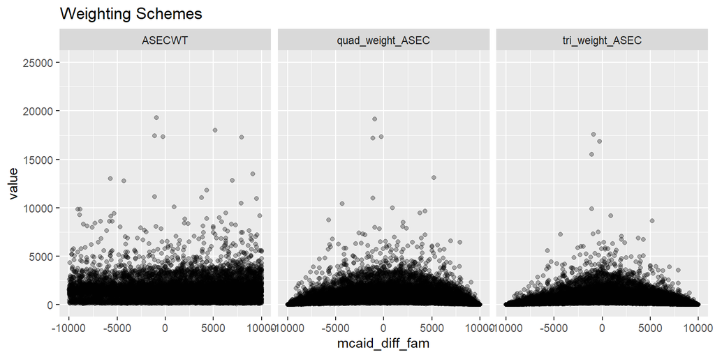

Finally, these models look at aggregate effects across the entire near-Medicaid workforce, including those above but near the threshold. This presents two key problems with causal inference. The near-medicaid population is, by definition, living near-poverty, meaning other state-level or macroeconomic changes may affect labor outcomes. Merely running the same regression on those strictly below the Medicaid threshold will increase the intensity of this selection effect.

Secondly, this data is not linked and the incomes measured in the data are within a tight band. Though incomes are relatively sticky, workers could easily have moved across or within the $10,000 threshold region over the time period studied. To account for this, testing against incomes well-above the threshold will work against this effect, though not perfectly.

To account for this, I employ a simple placebo testing framework. Setting a dummy variable equal to 1 if the observation is in the “above” threshold. With each observation taking a value of 1 or 0 for B = Placebo, P = Post, and T = Treat.

$H_{i,s,t} = \alpha + \theta_1 \cdot B + \theta_2 \cdot T + \theta_3 \cdot P + \theta_4 \cdot B \cdot T + \theta_5 \cdot B \cdot P + \theta_6 \cdot T \cdot P + \theta_7 \cdot B \cdot T \cdot P+ \mu_i + \epsilon$

$\theta_7$ is the triple-difference parameter of interest, which isolates the effect for low-income individuals against the effect for those sufficiently above the medicaid threshold. I also run this same model for those just above the medicaid threshold against those well-below to estimate whether those above adjusted income down to qualify for medicaid.

## Results

#### Diff-in-Diff regressions

```
##
## Table 1: Diff-in-Diff Results
## ======================================================================================
##                                         Dependent variable:
##               ------------------------------------------------------------------------
##                                             Weekly Hours
##                   Basic DiD        Event Study    Triangular Weights Quadratic Weights
##                      (1)               (2)               (3)                (4)
## --------------------------------------------------------------------------------------
## DiD Estimator 2.454*** (0.169)
## Year 0                          2.978*** (0.202)   3.346*** (0.204)  3.189*** (0.203)
## Year 1                          2.873*** (0.262)   3.055*** (0.265)  2.984*** (0.264)
## Year 2                          2.979*** (0.265)   2.993*** (0.268)  2.921*** (0.267)
## Year 3                          2.381*** (0.283)   2.719*** (0.288)  2.601*** (0.287)
## Year 4                          2.478*** (0.293)   3.116*** (0.301)  2.978*** (0.299)
## Year 5                          2.073*** (0.334)   2.251*** (0.339)  2.238*** (0.339)
## Intercept     36.528*** (0.460) 36.539*** (0.459) 35.932*** (0.476)  36.120*** (0.474)
## --------------------------------------------------------------------------------------
## Observations       96,543            96,543             96,543            96,543
## ======================================================================================
## Note:                                                      *p<0.1; **p<0.05; ***p<0.01
```

Regardless of weighting scheme, the same 2-3 hour difference appears in each regression. This in important in two ways. First, it validates the theoretical notion that those closer to the relevant constraint will be more sensitive to it.

Secondly, the triangular weighting scheme’s effectiveness both motivates and gives validity to a placebo test. Under a circumstance where those far from the cutoff are driving results, an effective placebo group would not be available. In this case, with the effect concentrated at the cutoff, those far from the cutoff can serve as a placebo.

Table 2 shows two placebo tests, breaking out the group “just below” and “just above” the cutoff to further isolate the effects of expansion. Placebo groups were selected across the threshold and sufficiently far away.

#### Placebo Regressions

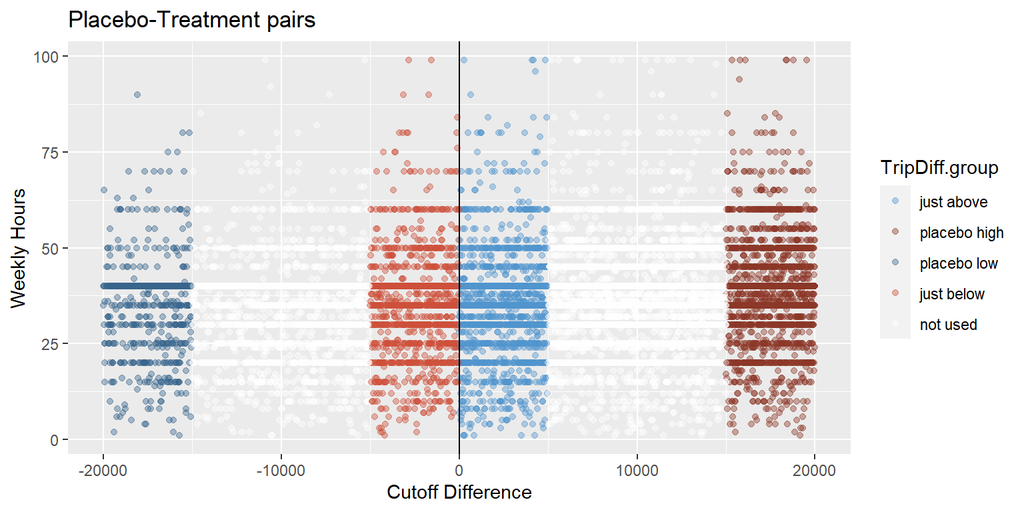

```
##
## Table 2: Triple-Diff Results
## =========================================================================
##                                      Dependent variable:
##                     -----------------------------------------------------
##                                         Weekly Hours
##                             Just Below                 Just Above
##                                (1)                        (2)
## -------------------------------------------------------------------------
## Constant                40.848*** (0.446)          34.917*** (1.058)
## Treatment                 -0.458 (0.653)             1.033 (1.299)
## Post                    -2.805*** (0.323)          -10.841*** (1.208)
## Treated                 -4.607*** (0.244)           1.678** (0.660)
## Treatment * Post         1.151*** (0.211)           6.852*** (1.169)
## Treatment * Treated      1.722*** (0.279)           1.393** (0.701)
## Post * Treated          -1.919*** (0.397)           5.900*** (1.167)
## Triple Difference        2.007*** (0.442)          -4.118*** (1.209)
## -------------------------------------------------------------------------
## Observations                  61,517                     34,045
## R2                            0.096                      0.106
## Adjusted R2                   0.095                      0.104
## Residual Std. Error    388.132 (df = 61434)       421.758 (df = 33962)
## F Statistic         79.990*** (df = 82; 61434) 48.942*** (df = 82; 33962)
## =========================================================================
## Note:                                         *p<0.1; **p<0.05; ***p<0.01
```

Table 2 shows a very different effect depending on the relationship to the Medicaid cutoff. Those who are “just above” the cutoff reduce work hours by 3-5 hours per week while those “just below” increase hours by 1.5-2.5 hours.

### Conclusion

Low-income people in the United States face an impossible set of circumstances for healthcare, especially those in or near the Medicaid Gap. The ACA’s expansion of Medicaid eligibility to those at 138% of the federal poverty line represented a massive shift in access to medicine for some of the poorest families in America.

Previously it has been shown there is not a large amount of bunching along the Medicaid cutoff, partially due to the fluid nature of “potential” Medicaid coverage being enough for hospitals to treat patients. However, in the aggregate, there is evidence of people adjusting their behavior in response to the Medicaid cutoff.

Taking the placebo estimates from Table 2, the change in number of hours worked represents a substantial change in income over the year. By those estimates, at the average hourly wage for this cohort ($12), those “just below” the Medicaid cutoff increased yearly wages by $1,200 while maintaining pseudo-coverage on Medicaid.

Perhaps more starkly, those “just above” the threshold reduced income by $2,400. This is consistent with a rational, utility-maximizing consumer theory since the average cost of a health insurance plan is $6,000.

In a broader context, this shows the effectiveness of a healthcare system not linked to an employment scheme. Also, keeping in mind the kinds of positions which offer $12/hr tend not to be positions which offer generous benefits packages. Across this cohort, the only “work reducing” effect of this program is for those reducing labor output in order to get access to healthcare. The oppressive costs of healthcare in the United States have a massive distortionary effect on labor output, as illustrated in this relatively small example. Under a similar theory of healthcare access as a preferred outcome of a utility-maximizing household, there is reason to believe a similar effect is taking place among those in higher income cohorts as well.